# 30daymappinghousingchallenge

## Day 02 - Lines

```r
d02_work <- d02_data %>%
  group_by(FULL2_NAME) %>%
  summarise(totin = sum(MOVEDIN)) %>%
  rename("MOVEDFROM" = "FULL2_NAME") %>%
  mutate(MOVEDTO = "District") %>%
  filter(MOVEDFROM != "Pennsylvania" & MOVEDFROM != "Delaware" & MOVEDFROM != "New Jersey") %>%
  st_drop_geometry()

map_padenj <- map_states %>%
  filter(STUSPS == "PA" | STUSPS == "DE" | STUSPS == "NJ") %>%
  group_by() %>%
  summarise()

map_padenj_ctr <- map_padenj %>%
  st_centroid()

map_padenj_ctr <- extract(map_padenj_ctr, geometry, into = c('Lat', 'Lon'), '\\((.*),(.*)\\)', conv = T)

map_padenj_ctr <- map_padenj_ctr %>%
  mutate(MOVEDTO = "District") %>%
  rename(tolat = "Lat", tolon = "Lon")

map_states_ctr <- map_states %>%
  st_centroid() %>%
  dplyr::select(NAME) %>%
  rename("MOVEDFROM" = "NAME")

map_states_ctr <- extract(map_states_ctr, geometry, into = c('Lat', 'Lon'), '\\((.*),(.*)\\)', conv = T)

map_states_ctr <- map_states_ctr %>%
  rename(frlat = "Lat", frlon = "Lon")

d02_work_ <- inner_join(d02_work, map_padenj_ctr, by = "MOVEDTO")

d02_work_ <- inner_join(d02_work_, map_states_ctr, by = "MOVEDFROM")
```

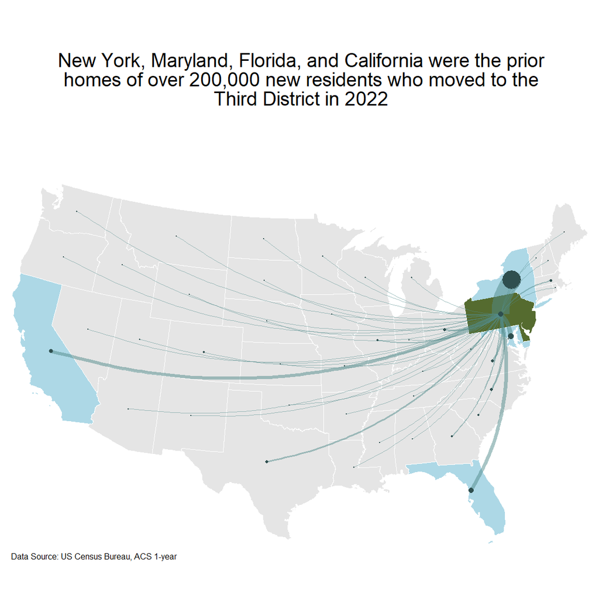

```r
day02_title <- "New York, Maryland, Florida, and California were the prior homes of over 200,000 new residents who moved to the Third District in 2022"

ggplot() +
  geom_sf(data = map_states, fill = if_else(map_states$STUSPS == "NY" | map_states$STUSPS == "MD" | map_states$STUSPS == "FL" | map_states$STUSPS == "CA", "lightblue", "gray90"), color = "transparent") +
  geom_sf(data = map_states, fill = "transparent", color = "white", size = 4) +
  geom_sf(data = map_padenj, fill = "darkolivegreen", color = "transparent") +
  geom_curve(data = d02_work_, aes(x = frlat, y = frlon, xend = tolat, yend = tolon), col = "darkslategray4", size = (d02_work_$totin/20000), alpha = 0.5, curvature = 0.2) +
  geom_point(data = d02_work_,
             aes(x = frlat, y = frlon),
             colour = "darkslategray",
             size = (d02_work_$totin/20000)) +
  geom_point(data = map_padenj_ctr,
             aes(x = tolat, y = tolon),
             colour = "darkslategray") +
  labs(title = day02_title,
       caption = "Data Source: US Census Bureau, ACS 1-year") +
  theme(plot.title = element_textbox_simple(size = 14, lineheight = 1, halign = 0.5, padding = margin(10, 30, 10, 30)),
        plot.caption = element_textbox_simple(size = 6),
        legend.position = "none",
        panel.background = element_blank(),
        axis.text.x = element_blank(),
        axis.text.y = element_blank(),
        axis.ticks.x = element_blank(),
        axis.ticks.y = element_blank(),
        axis.line = element_blank(),
        axis.title.x = element_blank(),
        axis.title.y = element_blank(),
        axis.ticks = element_blank()) +
  xlim(-2150000, 2074000) +
  ylim(400000.00, 3500000)
```

```r
ggsave(filename = "thumbnails/02_scurry_lines.png", width = 6, height = 6, dpi = 300)
```

See a lot of new faces in town lately? Who is moving to the tri-state area and from where are they coming? The largest number of newcomers are from New York, but Maryland, California, and Florida were also top contributors in 2022.

## Day 03 - Polygons

```r
d03_work <- d03_data %>%
  mutate(monthly_lw = (medsmocE/0.3)) %>%
  mutate(annual_lw = ((monthly_lw*12))) %>%
  mutate(lw_ratio = (medhhincE/annual_lw)) %>%
  st_transform(crs = 2272)
```

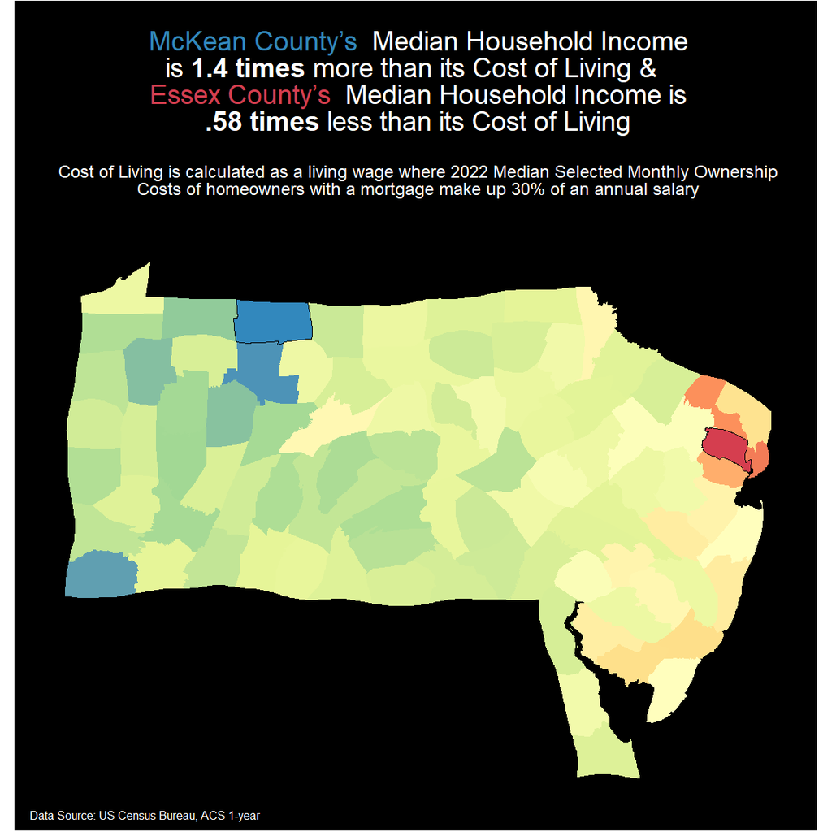

```r
d03_map <- cartogram_cont(d03_work, weight = "lw_ratio")

day03_title <- "<span style='color: #3288BD;'>McKean County's</span> <span style='color: #FFFFFF;'>Median Household Income is **1.4 times** more than its Cost of Living & </span> <span style='color: #D53E4F;'>Essex County's</span> <span style='color: #FFFFFF;'>Median Household Income is **.58 times** less than its Cost of Living</span>"

day03_subtitle <- "<span style='color: #FFFFFF;'>Cost of Living is calculated as a living wage where 2022 Median Selected Monthly Ownership Costs of homeowners with a mortgage make up 30% of an annual salary</span>"

day03_caption <- "<span style='color: #FFFFFF;'>Data Source: US Census Bureau, ACS 1-year</span>"

ggplot() +
  geom_sf(data = d03_map, aes(fill = lw_ratio), color = "transparent") +
  geom_sf(data = d03_map, fill = "transparent", color = if_else((d03_map$GEOID == "34013" | d03_map$GEOID == "42083"), "black", "transparent")) +
  scale_fill_distiller(palette = "Spectral", direction = 1) +
  labs(title = day03_title,
       subtitle = day03_subtitle,
       caption = day03_caption) +
  theme(plot.background = element_rect(fill = "black"),
        plot.title = element_textbox_simple(size = 14, lineheight = 1, halign = 0.5, padding = margin(10, 60, 10, 60)),
        plot.subtitle = element_textbox_simple(size = 9, lineheight = 1, halign = 0.5, padding = margin (5, 15, 20, 15)),
        plot.caption = element_textbox_simple(size = 6),
        legend.position = "none",
        panel.background = element_blank(),
        panel.grid.major = element_blank(),
        panel.grid.minor = element_blank(),
        axis.text.x = element_blank(),
        axis.text.y = element_blank(),
        axis.ticks = element_blank(),
        axis.ticks.x = element_blank(),
        axis.ticks.y = element_blank(),
        axis.line = element_blank(),
        axis.title.x = element_blank(),
        axis.title.y = element_blank())
```

```r
ggsave(filename = "thumbnails/03_scurry_polygons.png", width = 6, height = 6, dpi = 300)
```

There are many ways to measure the difference between household income and cost of living expenses. One method includes comparing actual income to a calculated salary required to not be cost-burdened by mortgage or rental payments. In McKean County, PA, folks have a low cost of living compared to their median income - while the cost of living in Essex County, NJ is actually higher than the median income.

## Day 04 - Hexagons

```r
d04_work <- d04_data %>%
  mutate(pcentwhite = totwhitepopE/totpopE,
         pcentnonwhite = 1-(totwhitepopE/totpopE),
         pcentblack = totblackpopE/totpopE) %>%
  mutate(coloroldbg = if_else(pcentnonwhite >= 0.50 & medyrbuiltE <= 1970, TRUE, FALSE)) %>%
  st_centroid()

d04_work <- extract(d04_work, geometry, into = c('Lat', 'Lon'), '\\((.*),(.*)\\)', conv = T)

map_phl_bound_4269 <- map_phl_bound %>%
  st_transform(crs = 4269)
```

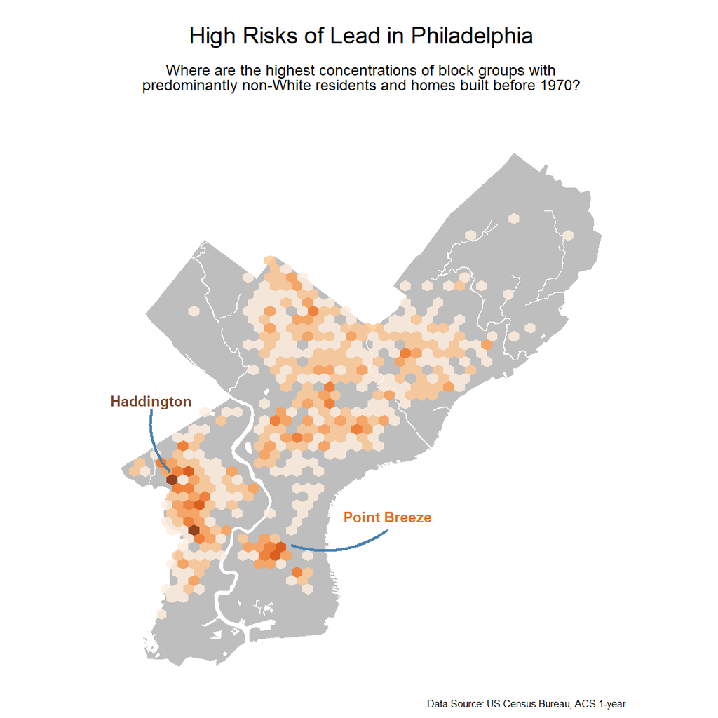

```r
# ggplot(data = d04_work %>%
#          filter(coloroldbg == TRUE), aes(x = Lat, y = Lon)) +
#   geom_point()

#Where are there a high concentration of block groups with predominantly nonwhite hh and median home built before 1970
ggplot() +
  geom_sf(data = map_phl_bound_4269, color = "white", fill = "gray") +
  geom_hex(data = d04_work %>%
         filter(coloroldbg == TRUE), aes(x = Lat, y = Lon), bins = 40, alpha = 0.85) +
  # ylim(39.9, 40.1) +
  # xlim(-75.3, -75) +
  scale_fill_distiller(palette = "Oranges", direction = 1) +
  annotate("text", x = -75.259, y = 40.01, label = "Haddington", color = "#7B452C", size = 3, fontface = "bold") +
  geom_curve(aes(x = -75.259, xend = -75.247, y = 40.005, yend = 39.973), color = "steelblue", size = 0.8, curvature = 0.25) +
#  annotate("text", x = -75.15, y = 39.9, label = "Cobbs Creek", color = "#7B452C", size = 3, fontface = "bold") +
  annotate("text", x = -75.1, y = 39.95, label = "Point Breeze", color = "#E36D26", size = 3, fontface = "bold") +
  geom_curve(aes(x = -75.1, xend = -75.165, y = 39.943, yend = 39.935), color = "steelblue", size = 0.8, curvature = -0.25) +
  labs(title = "High Risks of Lead in Philadelphia",
       subtitle = "Where are the highest concentrations of block groups with predominantly non-White residents and homes built before 1970?",
       caption = "Data Source: US Census Bureau, ACS 1-year") +
  theme(plot.title = element_textbox_simple(size = 14, lineheight = 1, halign = 0.5, padding = margin(10, 30, 5, 30)),
        plot.subtitle = element_textbox_simple(size = 9, lineheight = 1, halign = 0.5, padding = margin(5, 20, 20, 20)),
        plot.caption = element_textbox_simple(size = 6, lineheight = 1, halign = 1),
        legend.position = "none",
        panel.background = element_blank(),
        axis.text.x = element_blank(),
        axis.text.y = element_blank(),
        axis.ticks = element_blank(),
        axis.ticks.x = element_blank(),
        axis.ticks.y = element_blank(),
        axis.line = element_blank(),
        axis.title.x = element_blank(),
        axis.title.y = element_blank())
```

```r
ggsave(filename = "thumbnails/04_scurry_hexagons.png", width = 6, height = 6, dpi = 300)

# ggplot(data = d04_work, aes(x = medyrbuiltE, y = pcentnonwhite)) +
#   geom_hex()
```

Lead pipes have very detrimental effects on the health and wellbeing of residents in old cities like Philadelphia. Studies have repeatedly shown that people of color and those who live in homes built prior to anti-lead pipe laws in the 1970’s are especially at risk for the demonstrated ill effects. This map examines every Census Tract in Philadelphia County to determine if the area was majority non-White AND if the median construction year of homes there was older than 1970. The hex map reveals a density of tracts in West and South Philly that mark TRUE for that combined factor.

## Day 05 - Journey

```r
#https://www.census.gov/data/tables/2020/demo/metro-micro/commuting-flows-2020.html
#remove headers, footers, and convert Workers in Commuting Flow to Numeric column

d05_data <- read.csv(file = "data/d05_source.csv")

map_counties <- counties() %>%
  st_transform(crs = 5070)
```

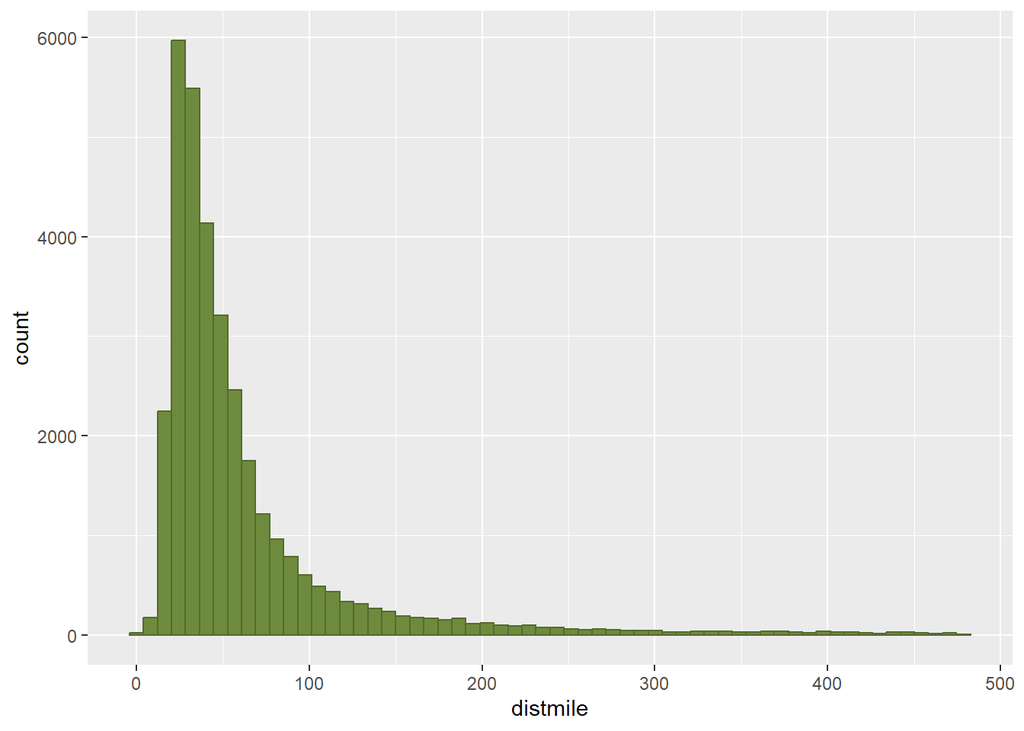

```r
d05_work <- d05_data %>%
  filter(Workers.in.Commuting.Flow > MOE) %>%
  drop_na(W.County.FIPS.Code) %>%
  mutate(R.GEOID = (1000 * R.State.FIPS.Code) + R.County.FIPS.Code,
         W.GEOID = (1000 * W.State.FIPS.Code) + W.County.FIPS.Code)

map_counties_ctr <- map_counties %>%
  mutate(R.GEOID = as.numeric(GEOID)) %>%
  st_centroid() %>%
  dplyr::select(R.GEOID)

map_counties_ctr <- tidyr::extract(map_counties_ctr, geometry, into = c('Lat', 'Lon'), '\\((.*),(.*)\\)', conv = T)

map_counties_ctr <- map_counties_ctr %>%
  rename(rlat = "Lat", rlon = "Lon")

d05_work <- inner_join(d05_work, map_counties_ctr, by = "R.GEOID", keep = TRUE)

map_counties_ctr <- map_counties_ctr %>%
  rename(wlat = "rlat", wlon = "rlon", W.GEOID = "R.GEOID")

d05_work <- inner_join(d05_work, map_counties_ctr, by = "W.GEOID", keep = FALSE)

d05_work <- d05_work %>%
  mutate(distmeter = pointDistance(d05_work[,c("rlat", "rlon")], d05_work[,c("wlat", "wlon")], lonlat = FALSE)) %>%
  mutate(distmile = distmeter/1609.34)

d05_work <- d05_work %>%
  filter(W.State.Name != "Hawaii" & W.State.Name != "Alaska" & W.State.Name != "Puerto Rico" &
           R.State.Name != "Hawaii" & R.State.Name != "Alaska" & R.State.Name != "Puerto Rico") %>%
  filter(distmile > 0 & distmile < 480)

ggplot() +
  geom_histogram(data = d05_work %>%
                   filter(distmile > 0 & distmile < 480), aes(x = distmile), fill = "darkolivegreen4", color = "darkolivegreen", bins = 60)
```

```r
quantile(d05_work$Workers.in.Commuting.Flow)
```

```
##     0%    25%    50%    75%   100%
##      3     60    145    466 451008
```

```r
quantile(d05_work$distmile)
```

```
##          0%         25%         50%         75%        100%
##   0.5687688  28.4384716  42.2705000  68.3758049 479.1469836
```

```r
d05_work <- d05_work %>%
  mutate(flowpercentile = case_when(Workers.in.Commuting.Flow <= quantile(d05_work$Workers.in.Commuting.Flow, 0.25) ~ "u25",
                                Workers.in.Commuting.Flow <= quantile(d05_work$Workers.in.Commuting.Flow, 0.50) ~ "u50",
                                Workers.in.Commuting.Flow <= quantile(d05_work$Workers.in.Commuting.Flow, 0.75) ~ "u75",
                                Workers.in.Commuting.Flow > quantile(d05_work$Workers.in.Commuting.Flow, 0.75) ~ "u100")) %>%
  mutate(distpercentile = case_when(distmile <= quantile(d05_work$distmile, 0.25) ~ "u25",
                                    distmile <= quantile(d05_work$distmile, 0.50) ~ "u50",
                                    distmile <= quantile(d05_work$distmile, 0.75) ~ "u75",
                                    distmile > quantile(d05_work$distmile, 0.75) ~ "u100"))
```

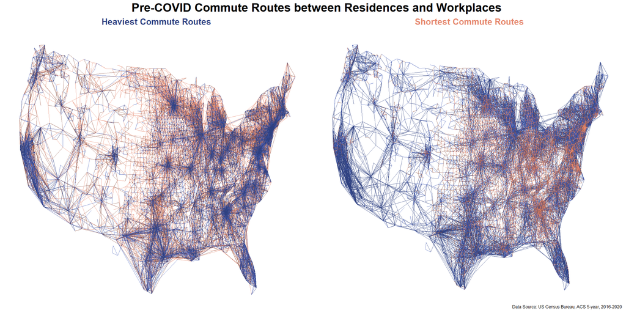

```r
#low = "lemonchiffon", mid = "darkolivegreen", high = "royalblue4"

#87AFD5
#4F7EAA
#265480
#0B3155

d05_mapa <- ggplot() +
  geom_segment(data = d05_work %>%
                 filter(flowpercentile == "u25"), aes(x = rlat, y = rlon, xend = wlat, yend = wlon), color = "#E5866C", size = 0.25, alpha = 0.75, curvature = 0.0) +
  geom_segment(data = d05_work %>%
                 filter(flowpercentile == "u50"), aes(x = rlat, y = rlon, xend = wlat, yend = wlon), color = "#8F5443", size = 0.25, alpha = 0.75, curvature = 0.0) +
  geom_segment(data = d05_work %>%
                 filter(flowpercentile == "u75"), aes(x = rlat, y = rlon, xend = wlat, yend = wlon), color = "#435DBA", size = 0.25, alpha = 0.75, curvature = 0.0) +
  geom_segment(data = d05_work %>%
                 filter(flowpercentile == "u100"), aes(x = rlat, y = rlon, xend = wlat, yend = wlon), color = "#2E4080", size = 0.25, alpha = 0.75, curvature = 0.0) +
#  coord_cartesian(xlim = c(-2150000, 2074000), ylim = c(400000, 3500000)) +
  labs(title = " ",
       subtitle = " ",
       caption = " ") +
  theme(plot.title = element_textbox_simple(size = 14, lineheight = 1, halign = 0.0, padding = margin(0, 0, 0, 0)),
        plot.subtitle = element_textbox_simple(size = 9, lineheight = 1, halign = 0.0, padding = margin(0, 0, 0, 0)),
        plot.caption = element_textbox_simple(size = 6, lineheight = 1, halign = 1),
        legend.position = "none",
        panel.background = element_blank(),
        axis.text.x = element_blank(),
        axis.text.y = element_blank(),
        axis.ticks = element_blank(),
        axis.ticks.x = element_blank(),
        axis.ticks.y = element_blank(),
        axis.line = element_blank(),
        axis.title.x = element_blank(),
        axis.title.y = element_blank())

d05_mapb <- ggplot() +
  geom_segment(data = d05_work %>%
                 filter(distpercentile == "u100"), aes(x = rlat, y = rlon, xend = wlat, yend = wlon), color = "#2E4080", size = 0.25, alpha = 0.75, curvature = 0.0) +
  geom_segment(data = d05_work %>%
                 filter(distpercentile == "u75"), aes(x = rlat, y = rlon, xend = wlat, yend = wlon), color = "#435DBA", size = 0.25, alpha = 0.75, curvature = 0.0) +
  geom_segment(data = d05_work %>%
                 filter(distpercentile == "u50"), aes(x = rlat, y = rlon, xend = wlat, yend = wlon), color = "#8F5443", size = 0.25, alpha = 0.75, curvature = 0.0) +
  geom_segment(data = d05_work %>%
                 filter(distpercentile == "u25"), aes(x = rlat, y = rlon, xend = wlat, yend = wlon), color = "#E5866C", size = 0.25, alpha = 0.75, curvature = 0.0) +
#  coord_cartesian(xlim = c(-2150000, 2074000), ylim = c(400000, 3500000)) +
  labs(title = " ",
       subtitle = " ",
       caption = "Data Source: US Census Bureau, ACS 5-year, 2016-2020") +
  theme(plot.title = element_textbox_simple(size = 14, lineheight = 1, halign = 0.0, padding = margin(0, 0, 0, 0)),
        plot.subtitle = element_textbox_simple(size = 9, lineheight = 1, halign = 0.0, padding = margin(0, 0, 0, 0)),
        plot.caption = element_textbox_simple(size = 6, lineheight = 1, halign = 1),
        legend.position = "none",
        panel.background = element_blank(),
        axis.text.x = element_blank(),
        axis.text.y = element_blank(),
        axis.ticks = element_blank(),
        axis.ticks.x = element_blank(),
        axis.ticks.y = element_blank(),
        axis.line = element_blank(),
        axis.title.x = element_blank(),
        axis.title.y = element_blank())

d05_map_plotrow <- plot_grid(
  d05_mapa, d05_mapb,
  nrow = 1, ncol = 2, rel_widths = c(1, 1))

#label_color = c("#2E4080", "#E5866C")

d05_map_title <- ggdraw() +
  draw_label(
    "Pre-COVID Commute Routes between Residences and Workplaces",
    fontface = "bold",
    size = 16,
    x = 0.5,
    hjust = 0.5
  ) +
  theme(
    # add margin on the left of the drawing canvas,
    # so title is aligned with left edge of first plot
    plot.margin = margin(0, 0, 0, 10)
  )

d05_map_subtitlea <- ggdraw() +
  draw_label(
    "Heaviest Commute Routes",
    fontface = "bold",
    color = "#2E4080",
    size = 12,
    x = 0.5,
    hjust = 0.5
  )

d05_map_subtitleb <- ggdraw() +
  draw_label(
    "Shortest Commute Routes",
    fontface = "bold",
    color = "#E5866C",
    size = 12,
    x = 0.5,
    hjust = 0.5
  )

d05_map_subtitle <- plot_grid(
  d05_map_subtitlea, d05_map_subtitleb,
  ncol = 2, nrow = 1, rel_widths = c(6, 6)
)

d05_map_top <- plot_grid(
  d05_map_title, d05_map_subtitle,
  ncol = 1, nrow = 2, rel_heights = c(1, 1)
)

plot_grid(
  d05_map_top, d05_map_plotrow,
  ncol = 1, nrow = 2, rel_heights = c(0.1, 1)
)
```

```r
ggsave(filename = "thumbnails/05_scurry_journey.png", width = 12, height = 6, dpi = 300)
```

## Day 12 - TimeAndSpace

```r
d12_data <- read.csv(file = "data/d12_source.csv")
```

```r
d12_work <- d12_data %>%
  filter(yr_pis != 8888 & yr_pis != 9999) %>%
  drop_na(latitude)

d12_work <- d12_work %>%
  st_as_sf(coords = c("longitude", "latitude"), crs = 4269) %>%
  st_transform(crs = 5070)

d12_work <- d12_work %>%
  mutate(decade = case_when(yr_pis <= 1989 ~ 1980,
                            yr_pis <= 1999 ~ 1990,
                            yr_pis <= 2009 ~ 2000,
                            yr_pis <= 2019 ~ 2010,
                            yr_pis <= 2029 ~ 2020))

map_pa <- map_states %>%
  filter(STUSPS == "PA")
```

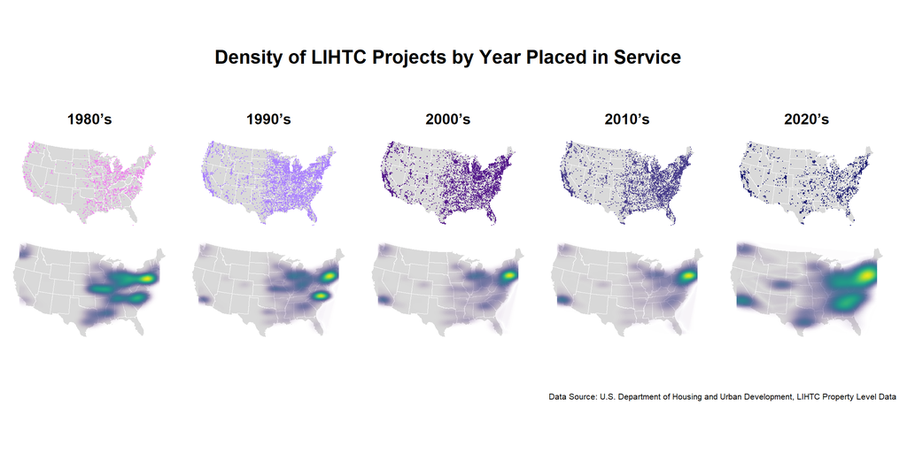

```r
# Uses grid.arrange to organize independent plots


  # Plot 1: Burglaries overlaid on Chicago boundary
d12_mapa <- ggplot() +
    geom_sf(data = map_states, fill = "gray85", color = "white") +
    geom_sf(data = d12_work %>%
              filter(decade == 1980), color = "violet", size = 0.1) +
    labs(title = "1980's") +
  xlim(-2150000, 2074000) +
  ylim(400000.00, 3500000) +
  theme_void() +
  theme(plot.title = element_textbox_simple(size = 14, face = "bold", lineheight = 1, halign = 0.5, padding = margin(0, 0, 0, 0)),
        plot.margin = margin(0, 0, 0, 0),
        legend.position = "none")

d12_mapb <- ggplot() +
    geom_sf(data = map_states, fill = "gray85", color = "white") +
    geom_sf(data = d12_work %>%
              filter(decade == 1990), color = "mediumpurple1", size = 0.1) +
    labs(title = "1990's") +
  xlim(-2150000, 2074000) +
  ylim(400000.00, 3500000) +
    theme_void() +
  theme(plot.title = element_textbox_simple(size = 14, face = "bold", lineheight = 1, halign = 0.5, padding = margin(0, 0, 0, 0)),
        plot.margin = margin(0, 0, 0, 0),
        legend.position = "none")

d12_mapc <- ggplot() +
    geom_sf(data = map_states, fill = "gray85", color = "white") +
    geom_sf(data = d12_work %>%
              filter(decade == 2000), color = "purple4", size = 0.1) +
    labs(title = "2000's") +
  xlim(-2150000, 2074000) +
  ylim(400000.00, 3500000) +
    theme_void() +
  theme(plot.title = element_textbox_simple(size = 14, face = "bold", lineheight = 1, halign = 0.5, padding = margin(0, 0, 0, 0)),
        plot.margin = margin(0, 0, 0, 0),
        legend.position = "none")

d12_mapd <- ggplot() +
    geom_sf(data = map_states, fill = "gray85", color = "white") +
    geom_sf(data = d12_work %>%
              filter(decade == 2010), color = "slateblue4", size = 0.1) +
    labs(title = "2010's") +
  xlim(-2150000, 2074000) +
  ylim(400000.00, 3500000) +
    theme_void() +
  theme(plot.title = element_textbox_simple(size = 14, face = "bold", lineheight = 1, halign = 0.5, padding = margin(0, 0, 0, 0)),
        plot.margin = margin(0, 0, 0, 0),
        legend.position = "none")

d12_mape <- ggplot() +
    geom_sf(data = map_states, fill = "gray85", color = "white") +
    geom_sf(data = d12_work %>%
              filter(decade == 2020), color = "midnightblue", size = 0.1) +
    labs(title = "2020's") +
  xlim(-2150000, 2074000) +
  ylim(400000.00, 3500000) +
    theme_void() +
  theme(plot.title = element_textbox_simple(size = 14, face = "bold", lineheight = 1, halign = 0.5, padding = margin(0, 0, 0, 0)),
        plot.margin = margin(0, 0, 0, 0),
        legend.position = "none")

nbins <- 80
  # Plot 2: Density of burglaries with contours overlaid on Chicago boundary
d12_mapf <- ggplot() +
    geom_sf(data = map_states, fill = "gray85", color = "white") +
    stat_density2d(data = data.frame(st_coordinates(d12_work %>%
              filter(decade == 1980))),  # Compute 2D kernel density estimate
                   aes(X, Y, fill = ..level.., alpha = ..level..),  # Define aesthetics for density contours
                   size = 0.01, bins = nbins, geom = 'polygon') +  # Set size and number of bins for contours
    scale_fill_viridis() +
    scale_alpha(range = c(0.00, 0.35), guide = FALSE) +  # Set transparency range for contours
  xlim(-2150000, 2074000) +
  ylim(400000.00, 3500000) +
    theme_void() +
  theme(plot.margin = margin(0, 0, 0, 0),
        legend.position = "none")

d12_mapg <- ggplot() +
    geom_sf(data = map_states, fill = "gray85", color = "white") +
    stat_density2d(data = data.frame(st_coordinates(d12_work %>%
              filter(decade == 1990))),  # Compute 2D kernel density estimate
                   aes(X, Y, fill = ..level.., alpha = ..level..),  # Define aesthetics for density contours
                   size = 0.01, bins = nbins, geom = 'polygon') +  # Set size and number of bins for contours
    scale_fill_viridis() +
    scale_alpha(range = c(0.00, 0.35), guide = FALSE) +  # Set transparency range for contours
  xlim(-2150000, 2074000) +
  ylim(400000.00, 3500000) +
    theme_void() +
  theme(plot.margin = margin(0, 0, 0, 0),
        legend.position = "none")

d12_maph <- ggplot() +
    geom_sf(data = map_states, fill = "gray85", color = "white") +
    stat_density2d(data = data.frame(st_coordinates(d12_work %>%
              filter(decade == 2000))),  # Compute 2D kernel density estimate
                   aes(X, Y, fill = ..level.., alpha = ..level..),  # Define aesthetics for density contours
                   size = 0.01, bins = nbins, geom = 'polygon') +  # Set size and number of bins for contours
    scale_fill_viridis() +
    scale_alpha(range = c(0.00, 0.35), guide = FALSE) +  # Set transparency range for contours
  xlim(-2150000, 2074000) +
  ylim(400000.00, 3500000) +
    theme_void() +
  theme(plot.margin = margin(0, 0, 0, 0),
        legend.position = "none")

d12_mapi <- ggplot() +
    geom_sf(data = map_states, fill = "gray85", color = "white") +
    stat_density2d(data = data.frame(st_coordinates(d12_work %>%
              filter(decade == 2010))),  # Compute 2D kernel density estimate
                   aes(X, Y, fill = ..level.., alpha = ..level..),  # Define aesthetics for density contours
                   size = 0.01, bins = nbins, geom = 'polygon') +  # Set size and number of bins for contours
    scale_fill_viridis() +
    scale_alpha(range = c(0.00, 0.35), guide = FALSE) +  # Set transparency range for contours
  xlim(-2150000, 2074000) +
  ylim(400000.00, 3500000) +
    theme_void() +
  theme(plot.margin = margin(0, 0, 0, 0),
        legend.position = "none")

d12_mapj <- ggplot() +
    geom_sf(data = map_states, fill = "gray85", color = "white") +
    stat_density2d(data = data.frame(st_coordinates(d12_work %>%
              filter(decade == 2020))),  # Compute 2D kernel density estimate
                   aes(X, Y, fill = ..level.., alpha = ..level..),  # Define aesthetics for density contours
                   size = 0.01, bins = nbins, geom = 'polygon') +  # Set size and number of bins for contours
    scale_fill_viridis() +
    scale_alpha(range = c(0.00, 0.35), guide = FALSE) +  # Set transparency range for contours
  xlim(-2150000, 2074000) +
  ylim(400000.00, 3500000) +
    theme_void() +
  theme(plot.margin = margin(0, 0, 0, 0),
        legend.position = "none")

d12_map_title <- ggdraw() +
  draw_label(
    "Density of LIHTC Projects by Year Placed in Service",
    fontface = "bold",
    color = "black",
    size = 18,
    x = 0.5,
    hjust = 0.5
  )

d12_map_point <- plot_grid(
  d12_mapa, d12_mapb, d12_mapc, d12_mapd, d12_mape,
  align = "h",
  rel_heights = 1,
  ncol = 5, nrow = 1
  )

d12_map_density <- plot_grid(
  d12_mapf, d12_mapg, d12_maph, d12_mapi, d12_mapj,
  align = "h",
  rel_heights = 1,
  ncol = 5, nrow = 1
  )

d12_map_caption <- ggdraw() +
  draw_label(
    "Data Source: U.S. Department of Housing and Urban Development, LIHTC Property Level Data",
    fontface = "plain",
    color = "black",
    size = 8,
    x = 1,
    hjust = 1
  ) +
  theme(plot.margin = margin(0, 10, 0, 0))

plot_grid(
  d12_map_title, d12_map_point, d12_map_density, d12_map_caption,
  align = "v",
#  rel_heights = c(3, 1, 1, 6),
  ncol = 1, nrow = 4
)
```

```r
ggsave(filename = "thumbnails/12_scurry_timeandspace.png", width = 12, height = 6, dpi = 300)
```

Mapping where LIHTC projects have been implemented per decade reveals a serious density of affordable projects on the Eastern half of the United States and a fairly constant presence of projects along the West coast. From decade to decade, the Southern region’s introduction of LIHTC construction isn’t as strong between the 1990’s and the 2010’s, though there has been an increase in recent years.

## Day 13 - A New Tool

```r
#Source: https://www.realtor.com/research/data/

d13_data <- st_read(dsn = "https://econdata.s3-us-west-2.amazonaws.com/Reports/Core/RDC_Inventory_Core_Metrics_Zip_History.csv") %>%
  mutate(postal_code = as.numeric(postal_code))
map_zip <- zctas() %>%
  st_transform(crs = 5070) %>%
  mutate(postal_code = as.numeric(ZCTA5CE20))

map_zip_ctr <- map_zip %>%
  st_centroid()

map_zip_padenj <- st_intersection(map_zip_ctr, map_states)

map_zip_padenj <- map_zip_padenj %>%
  filter(STUSPS == "PA" | STUSPS == "DE" | STUSPS == "NJ") %>%
  mutate(postal_code = as.numeric(ZCTA5CE20)) %>%
  dplyr::select(GEOID, STUSPS, postal_code) %>%
  st_drop_geometry()

map_zip_padenj <- inner_join(map_zip, map_zip_padenj, by = "postal_code")

d13_data_work <- inner_join(map_zip_padenj, d13_data, by = "postal_code") %>%
  st_transform(crs = 2272)
```

```r
d13_data_202202 <- d13_data_work %>%
  filter(month_date_yyyymm == 202202) %>%
  dplyr::select(postal_code, GEOID, STUSPS, month_date_yyyymm, zip_name,
         median_listing_price, active_listing_count, median_days_on_market,
         new_listing_count, price_increased_count, price_reduced_count,
         median_listing_price_per_square_foot, median_square_feet,
         average_listing_price, total_listing_count)

d13_data_202410 <- d13_data_work %>%
  filter(month_date_yyyymm == 202410) %>%
  dplyr::select(postal_code, GEOID, STUSPS, month_date_yyyymm, zip_name,
         median_listing_price, active_listing_count, median_days_on_market,
         new_listing_count, price_increased_count, price_reduced_count,
         median_listing_price_per_square_foot, median_square_feet,
         average_listing_price, total_listing_count)

d13_data_22 <- d13_data_202202 %>%
  dplyr::select(postal_code, GEOID, STUSPS, "22median_listing_price" = median_listing_price,
                "22active_listing_count" = active_listing_count,
                "22total_listing_count" = total_listing_count) %>%
  mutate(`22median_listing_price` = as.numeric(`22median_listing_price`),
         `22active_listing_count` = as.numeric(`22active_listing_count`),
         `22total_listing_count` = as.numeric(`22total_listing_count`))

d13_data_24 <- d13_data_202410 %>%
  dplyr::select(postal_code, "24median_listing_price" = median_listing_price,
                "24active_listing_count" = active_listing_count,
                "24total_listing_count" = total_listing_count) %>%
  mutate(`24median_listing_price` = as.numeric(`24median_listing_price`),
         `24active_listing_count` = as.numeric(`24active_listing_count`),
         `24total_listing_count` = as.numeric(`24total_listing_count`)) %>%
  st_drop_geometry()

d13_data_map <- left_join(d13_data_22, d13_data_24, by = "postal_code")

d13_data_map <- d13_data_map %>%
  mutate(diff_median_listing_price = `24median_listing_price` - `22median_listing_price`,
         diff_active_listing_count = `24active_listing_count` - `22active_listing_count`,
         diff_total_listing_count = `24total_listing_count` - `22total_listing_count`) %>%
  mutate(factor_mlp = case_when(diff_median_listing_price <= 0 ~ as.factor("negative"),
                                diff_median_listing_price > 0 ~ as.factor("positive")),
         factor_alc = case_when(diff_active_listing_count <= 0 ~ as.factor("negative"),
                                diff_active_listing_count > 0 ~ as.factor("positive")),
         factor_tlc = case_when(diff_total_listing_count <= 0 ~ as.factor("negative"),
                                diff_total_listing_count > 0 ~ as.factor("positive")))

d13_data_map <- bi_class(d13_data_map, x = factor_alc, y = factor_mlp, dim = 2)

table(d13_data_map$bi_class)
```

```
##
##   1-1   1-2  1-NA   2-1   2-2  2-NA NA-NA
##   141   340     1   314  1088     3   105
```

```r
#!883
```

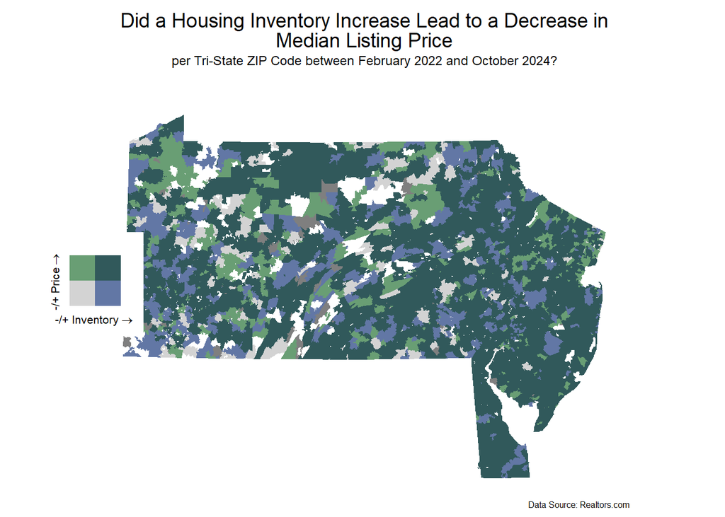

```r
d13_map <- ggplot() +
    geom_sf(data = d13_data_map, aes(fill = bi_class), color = "transparent", size = 0.1, show.legend = FALSE) +
  bi_scale_fill(pal = "DkCyan2", dim = 2) +
  labs(
    title = "Did a Housing Inventory Increase Lead to a\n Decrease in Median Listing Price",
    subtitle = "per Tri-State ZIP Code between February 2022 and October 2024?",
    caption = "Data Source: Realtors.com"
  ) +
  theme(plot.title = element_textbox_simple(size = 14, lineheight = 1, halign = 0.5, padding = margin(10, 0, 5, 0)),
        plot.subtitle = element_textbox_simple(size = 9, lineheight = 1, halign = 0.5, padding = margin(5, 0, 20, 0)),
        plot.caption = element_textbox_simple(size = 6, lineheight = 1, halign = 1),
        legend.position = "none",
        panel.background = element_blank(),
        axis.text.x = element_blank(),
        axis.text.y = element_blank(),
        axis.ticks = element_blank(),
        axis.ticks.x = element_blank(),
        axis.ticks.y = element_blank(),
        axis.line = element_blank(),
        axis.title.x = element_blank(),
        axis.title.y = element_blank())

d13_legend <- bi_legend(pal = "DkCyan2",
                    dim = 2,
                    xlab = "-/+ Inventory",
                    ylab = "-/+ Price",
                    size = 8)

d13_plot <- ggdraw() +
  draw_plot(d13_map, 0, 0, 1, 1) +
  draw_plot(d13_legend, 0.02, .35, 0.2, 0.2)

d13_plot
```

```r
ggsave(filename = "thumbnails/13_scurry_anewtool.png", width = 12, height = 6, dpi = 300)
```

Many experts say that housing prices will decrease once inventory increases. According to Realtor.com, the amount of housing inventory for sale in the United States since 2016 was most scarce during February of 2022. Per ZIP code in the tri-state region, which areas have seen housing inventory increases and median listing price decreases?

During the study period and within the study area, inventory counts and median prices behaved as predicted - either median price increased when inventory decreased or median price decreased when inventory increased - in 35% of recorded cases. More frequently, in areas across the tri-state area where inventory increased, the median price also increased, which occurred in about 58% of recorded cases.

## Day 22 - 2 Colors

```r
d22_data <- st_read(dsn = "https://services.arcgis.com/fLeGjb7u4uXqeF9q/arcgis/rest/services/AffordableHousingProduction/FeatureServer/0/query?outFields=*&where=1%3D1&f=geojson")
```

```
## replacing null geometries with empty geometries
## Simple feature collection with 462 features and 12 fields (with 20 geometries empty)
## Geometry type: POINT
## Dimension:     XY
## Bounding box:  xmin: -75.2489 ymin: 39.90183 xmax: -74.9829 ymax: 40.12171
## Geodetic CRS:  WGS 84
```

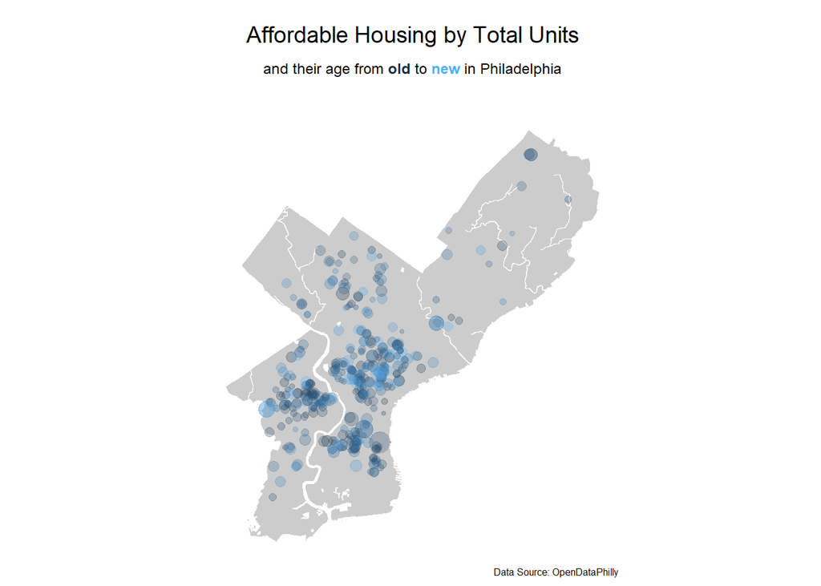

```r
new_color <- "#55AFF4"
old_color <- "#142D45"
day22_subtitle <- "and their age from <span style='color: #142D45;'>**old**</span> to <span style='color: #55AFF4;'>**new**</span> in Philadelphia"

ggplot() +
  geom_sf(data = map_phl_bound, fill = "gray80", color = "white") +
  geom_sf(data = d22_data %>% filter(status == "Complete"), aes(color = fiscal_year_complete, size = total_units), alpha = 0.25) +
  labs(title = "Affordable Housing by Total Units",
       subtitle = day22_subtitle,
       caption = "Data Source: OpenDataPhilly") +
  theme(plot.title = element_textbox_simple(size = 14, lineheight = 1, halign = 0.5, padding = margin(10, 0, 5, 0)),
        plot.subtitle = element_textbox_simple(size = 9, lineheight = 1, halign = 0.5, padding = margin(5, 20, 20, 20)),
        plot.caption = element_textbox_simple(size = 6, lineheight = 1, halign = 1),
        legend.position = "none",
        panel.background = element_blank(),
        axis.text.x = element_blank(),
        axis.text.y = element_blank(),
        axis.ticks = element_blank(),
        axis.ticks.x = element_blank(),
        axis.ticks.y = element_blank(),
        axis.line = element_blank(),
        axis.title.x = element_blank(),
        axis.title.y = element_blank())
```

```r
ggsave(filename = "thumbnails/22_scurry_twocolors.png", width = 6, height = 6, dpi = 300)
```

This map depicts the locations of PHA-owned affordable housing facilities throughout Philadelphia sorted by age. The newer buildings appear to be located most densely in Center City and West Philly, while the older projects are mostly distributed in South Philly and also in West Philly. The dearth of affordable housing is visible in the northeast region.

## Day 25 - Heat

```r
#Source: https://opendataphilly.org/datasets/heat-vulnerability-by-census-tract/

d25_data_heat <- st_read(dsn = "data/d25_source.geojson")
st_crs(d25_data_heat)
```

```
## Coordinate Reference System:
##   User input: WGS 84
##   wkt:
## GEOGCRS["WGS 84",
##     DATUM["World Geodetic System 1984",
##         ELLIPSOID["WGS 84",6378137,298.257223563,
##             LENGTHUNIT["metre",1]]],
##     PRIMEM["Greenwich",0,
##         ANGLEUNIT["degree",0.0174532925199433]],
##     CS[ellipsoidal,2],
##         AXIS["geodetic latitude (Lat)",north,
##             ORDER[1],
##             ANGLEUNIT["degree",0.0174532925199433]],
##         AXIS["geodetic longitude (Lon)",east,
##             ORDER[2],
##             ANGLEUNIT["degree",0.0174532925199433]],
##     ID["EPSG",4326]]
```

```r
d25_data_crime <- read.csv(file = "data/d25_source_crime.csv")
```

```r
table(d25_data_crime$text_general_code)
```

```
##
##              Aggravated Assault Firearm           Aggravated Assault No Firearm
##                                    2799                                    5575
##                      All Other Offenses                                   Arson
##                                   14218                                     718
##                Burglary Non-Residential                    Burglary Residential
##                                    1577                                    3456
##                      Disorderly Conduct             DRIVING UNDER THE INFLUENCE
##                                     458                                     881
##                            Embezzlement              Forgery and Counterfeiting
##                                     197                                     159
##                                   Fraud                     Gambling Violations
##                                    8578                                      83
##                     Homicide - Criminal                  Homicide - Justifiable
##                                     261                                       1
##                   Liquor Law Violations                     Motor Vehicle Theft
##                                     100                                   14649
##          Narcotic / Drug Law Violations    Offenses Against Family and Children
##                                    2936                                     366
##                          Other Assaults Other Sex Offenses (Not Commercialized)
##                                   27320                                    1178
##    Prostitution and Commercialized Vice                      Public Drunkenness
##                                     258                                      39
##                                    Rape               Receiving Stolen Property
##                                     531                                    1268
##                         Robbery Firearm                      Robbery No Firearm
##                                    1687                                    2626
##                      Theft from Vehicle                                  Thefts
##                                   10805                                   40280
##                      Vagrancy/Loitering             Vandalism/Criminal Mischief
##                                      20                                   14069
##                       Weapon Violations
##                                    2677
```

```r
d25_data_crime_work <- d25_data_crime %>%
  filter(text_general_code == "Aggravated Assault Firearm" | text_general_code == "Robbery Firearm") %>%
  na.omit("lat") %>%
  st_as_sf(coords = c("lng", "lat"), crs = 4326) %>%
  st_transform(crs = st_crs(d25_data_heat))
```

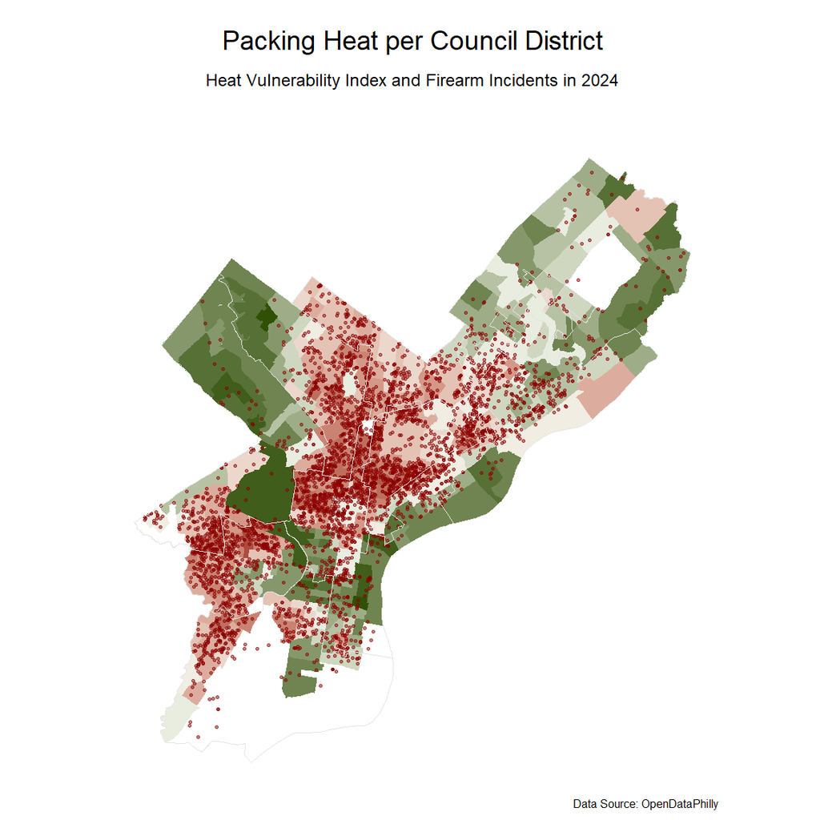

```r
ggplot() +
  geom_sf(data = d25_data_heat, aes(fill = hvi_score), color = "transparent") +
  scale_fill_steps2(low = "#2C4D00", mid = "#F5F8EF", high = "#AA4639", midpoint = 0, na.value = "white", breaks = seq(-8, 8, 1)) +
  geom_sf(data = d25_data_crime_work, aes(geometry = d25_data_crime_work$geometry), color = "darkred", size = 0.5, alpha = 0.5) +
  geom_sf(data = phlcouncildistricts, fill = "transparent", color = "gray90", size = 12) +
  labs(title = "Packing Heat per Council District",
       subtitle = "Heat Vulnerability Index and Firearm Incidents in 2024",
       caption = "Data Source: OpenDataPhilly") +
  theme(plot.title = element_textbox_simple(size = 14, lineheight = 1, halign = 0.5, padding = margin(10, 30, 5, 30)),
        plot.subtitle = element_textbox_simple(size = 9, lineheight = 1, halign = 0.5, padding = margin(5, 20, 20, 20)),
        plot.caption = element_textbox_simple(size = 6, lineheight = 1, halign = 1),
        legend.position = "none",
        panel.background = element_blank(),
        axis.text.x = element_blank(),
        axis.text.y = element_blank(),
        axis.ticks = element_blank(),
        axis.ticks.x = element_blank(),
        axis.ticks.y = element_blank(),
        axis.line = element_blank(),
        axis.title.x = element_blank(),
        axis.title.y = element_blank())
```

```r
ggsave(filename = "thumbnails/25_scurry_heat.png", width = 6, height = 6, dpi = 300)
```

Several studies show that hotspots for crime are colocated in places where there is little tree cover. Synonymously (and in keeping with the day’s theme), it could also be theorized that crimes that occur with firearms might be colocated where heat vulnerability is high. This map aims to begin to test that hypothesis, acknowledging that correlation does not equal causation.